# Lesson: Groups and Positions in Networks

2022-03-27

# 1 Categories Everywhere

A common feature of social life is to divide people into *categories*. For instance, there are *ethnoracial* categories (like Black, Asian, Hispanic, Pacific Islander), there are *ethnonational* categories (Philipino, Puerto Rican, Taiwanese, Nigerian, etc.), *ethnolinguistic* categories (based on the language(s) you speak), and *ethnoreligious* categories (based on the religion you practice). People also divide themselves into *gender identity* or *sexual orientation* categories. Sociologists like to divide up people based on things like categories based on such markers of “social position” like *occupation*, *education*, and *social class*. In the news, sometimes you hear about battles between “Millennials” (who kill everything) and out of touch “Boomers” (who hate everything), with sarcastic “Gen-Exers” in between. This is nothing but a division of people into categories based on *age* and *generation* (sometimes also referred to as *cohort*). The possibilities are endless!

Why are sociologists (and people) so obsessed with dividing up people into categories? Well, the basic idea is that category labels provide a mechanism to explain *group formation*, and they allow for sociologists to get a sense of the *position* people occupy in society. For instance, following the principle of **homophily** discussed in the lesson of ego networks, we may surmise that race, gender, and generation serve as principles of group formation (so that groups tend to be homogeneous with respect to age, gender, and generation). We may also say that a stockbroker who makes 500K a year and lives in Malibu occupies a very different **social position** than a high-school teacher who makes 50K a year and lives in the valley.

# 2 The Anti-Categorical Imperative

Social network analysis rejects the idea that the best way to divide up people into categories is to use pre-existing labels. This penchant has been labeled (riffing on the philosopher Immanuel Kant) the **anti-categorical imperative** (Emirbayer and Goodwin 1994). It is not that social network analysts necessarily reject the idea that people can be divided up into groups or that we should try to get a sense of the social position that people occupy. Instead, what network analysts insist on is that we should use the *pattern of interconnections* in social networks to come up with groups and assign people to social positions.

Emirbayer, Mustafa, and Jeff Goodwin. 1994. “Network Analysis, Culture, and the Problem of Agency.” *American Journal of Sociology* 99 (6): 1411–54.

At its simplest, then, finding groups and assigning nodes to social position boil down to the same thing, which is to take the initial set of nodes in the graph and divide them up into (some times mutually exclusive, sometimes overlapping) **subsets**, so that nodes in the same subset belong to the same group or occupy the same social position in the network.

In network terms, then, what is the difference between being in the same **group** and occupying the same **social position**? Just like with the traditional sociological conceptions, the key difference is that belonging to the same group logically implies that you share a lot of connections with the other people in your group (e.g., a group of friends is necessarily linked to one another). However, being in the same social position does not require that you are connected to others in your same position. For instance, you can be doctor in New York City and share the same social position with a doctor in Los Angeles without necessarily being connected to that person. So in network analysis, nodes in a network who share the same position have *similar patterns of connectivity with others* without necessarily being connected to one another (although they could be!).

So the group and the social position imagery leads to two distinct ways of **partitioning** (a fancy word for “splitting”) the nodes in a graph (representing a social network) into subsets. One based on whether the subsets are strongly interconnected among themselves (the *group approach*) or whether the subsets have similar patterns of connectivity with others (the *position approach*). While the group approach is *global* (it uses information from the connectivity structure of the whole graph), the position approach is *local* (it uses information from the local neighborhoods of each node to assign them to categories). They are many versions of the group approach, but only two main versions of the position approach. In this lesson, we will cover the main varieties of the group approach and the two flavors of the position approach.

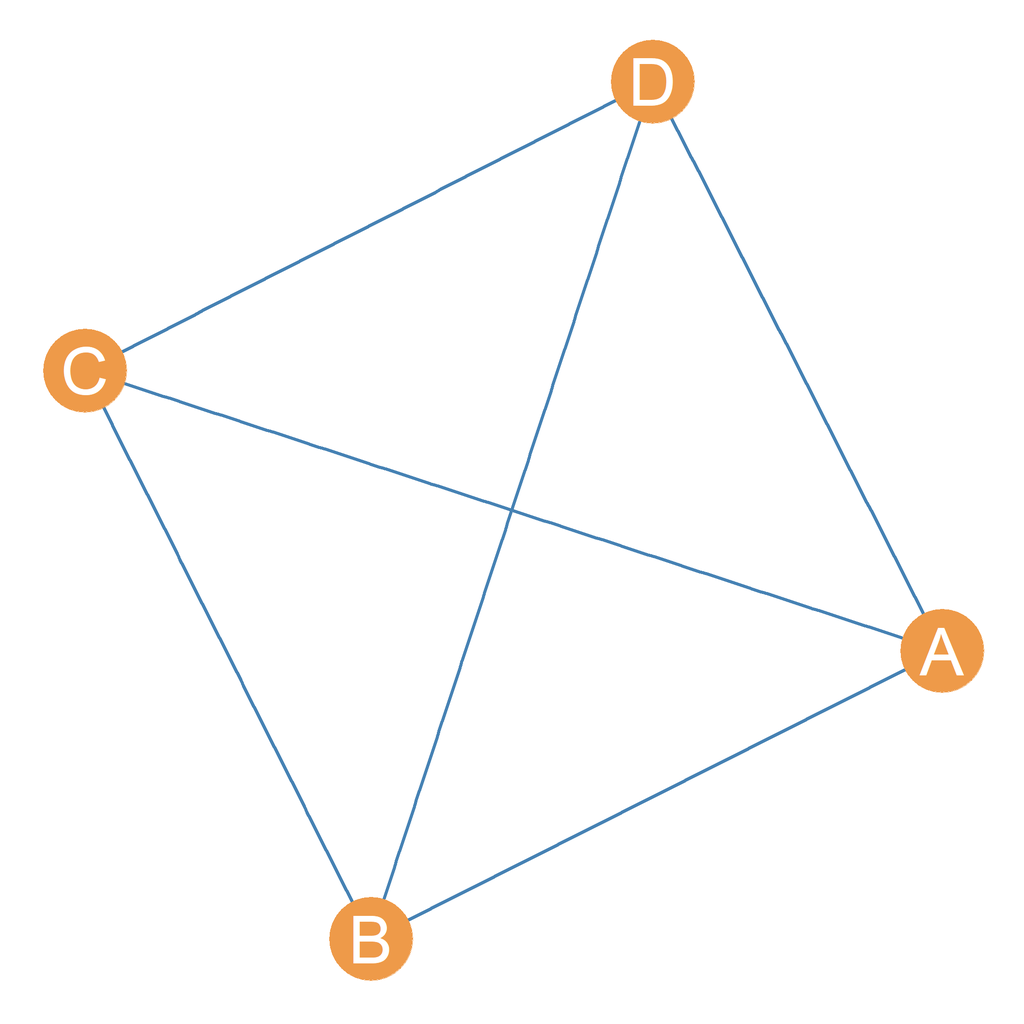

Figure 2.1: A clique of size four.

# 3 The Group Approach

The basic idea behind the group approach is to find **densely connected subgraphs** in the original graph. Densely connected subgraphs are the social network equivalent of “groups” in the real world (Freeman 1992). Just like in the real world, people can belong to more than one group at a time.

Freeman, Linton C. 1992. “The Sociological Concept of" Group": An Empirical Test of Two Models.” *American Journal of Sociology* 98 (1): 152–66.

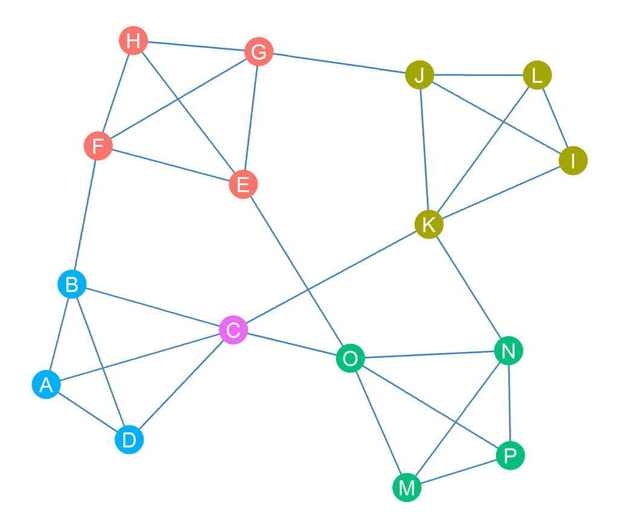

Figure 3.1: An undirected graph with four cliques of size 4.

The most densely connected subgraph in a graph is a subgraph with density equal to one. This is a **complete subgraph** of the larger graph. A complete subgraph of a larger graph is called a **clique** (Luce and Perry 1949). The identity of a clique is given by the nodes that are inside the clique. So when say that the set of nodes $\{A, B, C, D\}$ is a clique of size four with nodes *A*, *B*, *C*, and *D* inside of it. For instance, the subgraph shown in Figure 2.1 shows a clique of size four with nodes $\{A, B, C, D\}$ as members.

Luce, R Duncan, and Albert D Perry. 1949. “A Method of Matrix Analysis of Group Structure.” *Psychometrika* 14 (2): 95–116.

Cliques come in different sizes. A clique of size four is a **maximally complete subgraph** with four nodes in it. A complete subgraph of order five would yield a clique of size five and so forth. A subgraph is **maximal** for a given property (like being complete) if adding one more node to the subgraph gets rid of the property. For instance, a maximally complete subgraph of order four (a clique of size four) means that adding on more node to the subgraph would make its density drop below one, and thus the subgraph of order five is no longer complete.

Note that, technically, the **closed triad** we considered in the lesson on dyads and triads is a clique of size three!

Figure 3.1 shows a graph containing four separate cliques of size four, with nodes who belong to these four cliques highlighted in different colors. Nodes $\{A, B, C, D\}$ belong to one clique, nodes $\{E, F, G, H\}$, to another, nodes $\{I, J, K, L\}$ to yet another clique, and nodes $\{M, N, O, P\}$ to a final clique of size four.

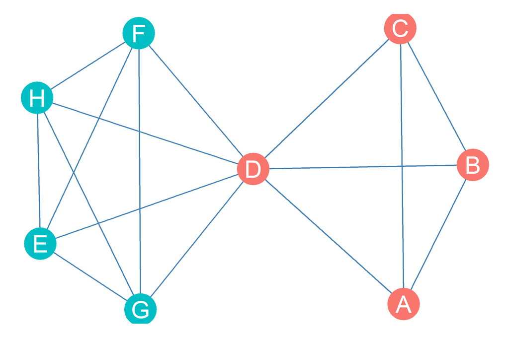

Figure 3.2: An undirected graph with two cliques, one of size four and the other one of size 5.

Nodes can belong to multiple cliques at once. This is for two reasons.

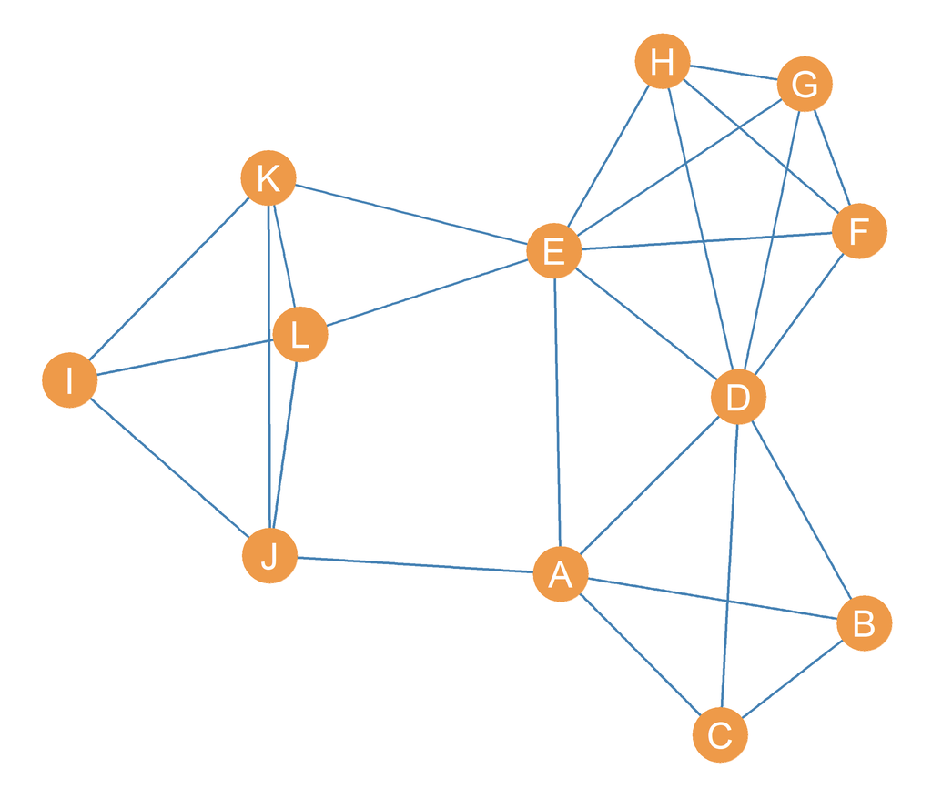

Figure 3.3: An undirected graph. How many cliques of size four or larger are there?

First, cliques of smaller size are nested within cliques of larger size. So inside a clique of size four like those formed by nodes $\{A, B, C, D\}$ in Figure 3.1, there are four separate cliques of size three: $\{A, B, C\}$, $\{B, C, D\}$, $\{A, B, D\}$, and $\{A, C, D\}$. So that means that each node in a clique of size four technically belongs four distinct cliques! The larger clique of size four and the three smaller cliques of size three.

The other reason nodes can be in multiple cliques is that the same node can be *shared* by multiple cliques even if the cliques are not nested. This situation is shown in Figure 3.2 where node *D* is shared by cliques $\{A, B, C, D\}$ and $\{D, E, F, G, H\}$. Using the set theory lingo we resorted to talk about node neighborhoods, another way of saying this is that the nodes shared by two cliques is given by the **intersection** of their set of members. So in the example shown in Figure 3.2:

$$\begin{equation}
\{D, E, F, G, H\} \cap \{A, B, C, D\} = D
\end{equation}$$

So there are eight cliques of size four or larger in the graph!

## 3.1 Cliques as Affliation Networks

There is a connection between cliques and **affiliation networks**. Recall from the lesson affiliation networks that we use these types of networks, represented using **bipartite graphs** whenever we want to highlight the linkages between *people* and *groups*. Well, cliques are groups, which means that the network formed by arranging people by their *membership* in cliques is an affiliation network!

Table 3.1: Person by clique affiliation matrix.

|  | C1 | C2 | C3 | C4 | C5 | C6 | C7 | C8 |
| --- | --- | --- | --- | --- | --- | --- | --- | --- |
| A | 0 | 0 | 0 | 1 | 0 | 0 | 0 | 0 |
| B | 0 | 0 | 0 | 1 | 0 | 0 | 0 | 0 |
| C | 0 | 0 | 0 | 1 | 0 | 0 | 0 | 0 |
| D | 1 | 1 | 0 | 1 | 1 | 0 | 1 | 1 |
| E | 1 | 1 | 0 | 0 | 0 | 1 | 1 | 1 |
| F | 1 | 0 | 0 | 0 | 1 | 1 | 1 | 1 |
| G | 1 | 1 | 0 | 0 | 1 | 1 | 1 | 0 |
| H | 1 | 1 | 0 | 0 | 1 | 1 | 0 | 1 |
| I | 0 | 0 | 1 | 0 | 0 | 0 | 0 | 0 |
| J | 0 | 0 | 1 | 0 | 0 | 0 | 0 | 0 |
| K | 0 | 0 | 1 | 0 | 0 | 0 | 0 | 0 |
| L | 0 | 0 | 1 | 0 | 0 | 0 | 0 | 0 |

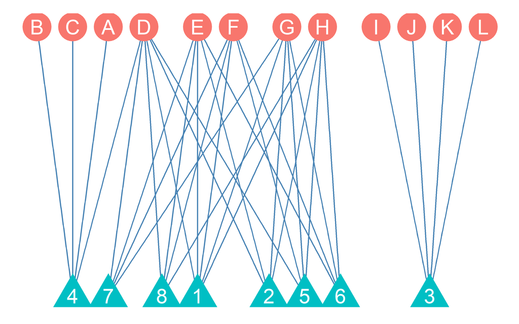

Figure 3.4: Bipartite graph of clique affliations.

Table 3.1 shows the **Clique Affiliation Matrix** ($C$) with people in the rows (*i*) and all the cliques of size four or larger in Figure 3.3 we listed previously (*j*) in the columns. Each cell entry $C_{ij}$ in the clique affiliation matrix is set to one if node *i* belongs to clique *j*. Otherwise it is set to zero.

As we can see, some nodes (like node *A*) belong to only one clique, but other nodes, like node *D* belongs to six cliques! This is consistent with the idea that while some people belong to just a few groups, other over-committed people belong to multiple groups. Figure 3.4 shows the corresponding bipartite graph displaying the clique affiliations in the network. People are shown as circles and cliques are shown as triangles.

Table 3.2: Clique co-membership matrix.

|  | A | B | C | D | E | F | G | H | I | J | K | L |
| --- | --- | --- | --- | --- | --- | --- | --- | --- | --- | --- | --- | --- |
| A | 1 | 1 | 1 | 1 | 0 | 0 | 0 | 0 | 0 | 0 | 0 | 0 |
| B | 1 | 1 | 1 | 1 | 0 | 0 | 0 | 0 | 0 | 0 | 0 | 0 |
| C | 1 | 1 | 1 | 1 | 0 | 0 | 0 | 0 | 0 | 0 | 0 | 0 |
| D | 1 | 1 | 1 | 6 | 4 | 4 | 4 | 4 | 0 | 0 | 0 | 0 |
| E | 0 | 0 | 0 | 4 | 5 | 4 | 4 | 4 | 0 | 0 | 0 | 0 |
| F | 0 | 0 | 0 | 4 | 4 | 5 | 4 | 4 | 0 | 0 | 0 | 0 |
| G | 0 | 0 | 0 | 4 | 4 | 4 | 5 | 4 | 0 | 0 | 0 | 0 |
| H | 0 | 0 | 0 | 4 | 4 | 4 | 4 | 5 | 0 | 0 | 0 | 0 |
| I | 0 | 0 | 0 | 0 | 0 | 0 | 0 | 0 | 1 | 1 | 1 | 1 |
| J | 0 | 0 | 0 | 0 | 0 | 0 | 0 | 0 | 1 | 1 | 1 | 1 |
| K | 0 | 0 | 0 | 0 | 0 | 0 | 0 | 0 | 1 | 1 | 1 | 1 |
| L | 0 | 0 | 0 | 0 | 0 | 0 | 0 | 0 | 1 | 1 | 1 | 1 |

Just like with regular affiliation networks, we can compute the matrix multiplication product of the clique affiliation matrix $C$ times its transpose $C'$. This gives us the **clique co-membership matrix** ($M$).

$$\begin{equation}
M = C \times C'
\tag{3.1}
\end{equation}$$

The off-diagonal cells of the clique co-membership matrix tell us the number of common cliques nodes *i* and *j* share, and the diagonal cells tell us the number of clique that each node belongs to. This is shown in Table 3.2.

Table 3.3: Clique overlap matrix.

|  | C1 | C2 | C3 | C4 | C5 | C6 | C7 | C8 |
| --- | --- | --- | --- | --- | --- | --- | --- | --- |
| C1 | 5 | 4 | 0 | 1 | 4 | 4 | 4 | 4 |
| C2 | 4 | 4 | 0 | 1 | 3 | 3 | 3 | 3 |
| C3 | 0 | 0 | 4 | 0 | 0 | 0 | 0 | 0 |
| C4 | 1 | 1 | 0 | 4 | 1 | 0 | 1 | 1 |
| C5 | 4 | 3 | 0 | 1 | 4 | 3 | 3 | 3 |
| C6 | 4 | 3 | 0 | 0 | 3 | 4 | 3 | 3 |
| C7 | 4 | 3 | 0 | 1 | 3 | 3 | 4 | 3 |
| C8 | 4 | 3 | 0 | 1 | 3 | 3 | 3 | 4 |

We can compute the matrix multiplication product of the transpose of the clique affiliation matrix $C'$ times the original matrix $C$. This gives us the **clique overlap matrix** ($O$).

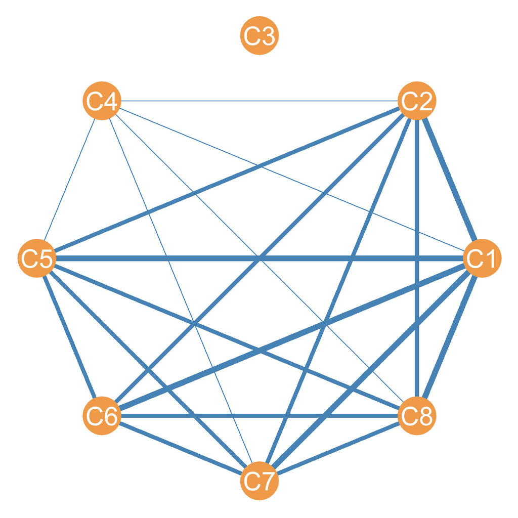

Figure 3.5: Clique graph.

$$\begin{equation}
O = C' \times C
\tag{3.2}
\end{equation}$$

The off-diagonal cells of the clique overlap matrix tell us the number of common members cliques *i* and *j* share, and the diagonal cells tell us size of each clique. This is shown in Table 3.3. Note that clique three is an isolate in the clique graph, as it shares no members with other cliques.

From this information we can construct what Everett and Borgatti (1998) call the **Clique Graph**. This is a weighted graph with cliques as the nodes and the edges weighted by the number of people shared by each clique. The clique graph corresponding to the clique affiliation matrix in Table 3.1 is shown in Figure 3.5.

Everett, Martin G, and Stephen P Borgatti. 1998. “Analyzing Clique Overlap.” *Connections* 21 (1): 49–61.

# 4 N-Cliques

Consider the network represented by the graph shown in Figure 4.1. In this figure, it is clear that the set of nodes $\{E, F, G, H\}$ are members of a clique of size four. But what about the set of nodes $\{A, B, C, D\}$? I mean, they do look “groupy” but they *technically* do not meet the requirements of a sociometric clique. The reason is that the subgraph formed by nodes $\{A, B, C, D\}$ is not complete (it is missing the edge $AC$) and thus has a density below one. However, we still have a strong intuition that there are pretty close to being a group.

Figure 4.1: A graph featuring n-cliques.

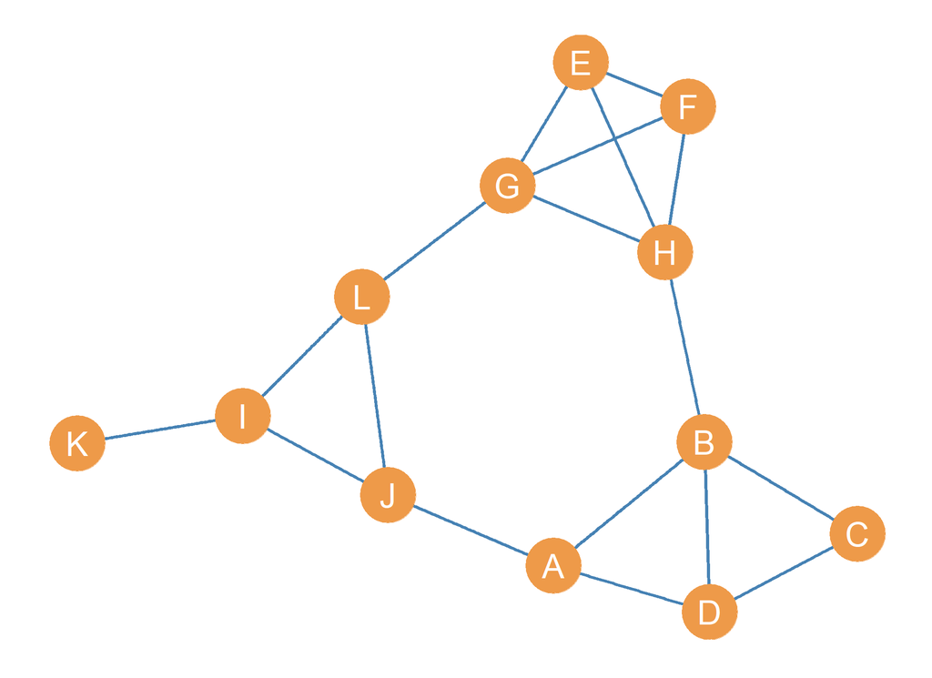

The mathematician Luce (1950) had the same intuition and that’s why he developed the notion of an **n-clique**. The basic idea is simple. Instead of defining a group based on a complete subgraph, we can define a group based on a subgraph with a (minimum) desired level of **indirect connectivity** (see the lesson on indirect connectivity), which we denote as *n*. For instance, we can say that any subset of nodes where every node in the subset is connected to every other node in the subset by a path of length two or smaller (which means a direct connection as an edge is a “path” of length one) form a **2-clique** ($n = 2$).

Luce, R Duncan. 1950. “Connectivity and Generalized Cliques in Sociometric Group Structure.” *Psychometrika* 15 (2): 169–90.

Note that the subgraph formed by the nodes $\{A, B, C, D\}$ meets this criterion: While node *A* is not connected to node *C*, it can reach node *C* by two paths of length two (either $\{AD, DC\}$ or $\{AB, BC\}$). Note that adding any other node to the subgraph (e.g., *J*, or *H*) breaks this property and no longer makes it a 2-clique. This means that the subgraph $\{A, B, C, D\}$ is maximal for the property of being a 2-clique

Can you see other subset of nodes in the graph that also form a 2-clique?

Hint: take a look at the “kite” subgraph formed by nodes $\{I, J, K, L\}$

Of course we can keep on going an make up even weaker and more relaxed definitions of a group based on the idea of indirect connectivity (e.g., $n = 3$, $n = 4$, and so forth). For instance, we can define a **3-clique** as any subgraph in which nodes are separated by a minimum of three steps (a path of length three). For instance, the hexagonal “ring” formed by the subgraph containing nodes $\{A, B, G, H, J, L\}$ in Figure 4.1 is such a 3-clique. Every actor can reach every other actor in the subgraph via a path of length 3 or smaller. Note that while this set of actors still looks kind of groupy (in a ring around the rosie kind of way) it does not look as much like a group as a 2-clique.

Of course, it would be silly to keep on going with larger values of n, since the subgraphs so defined would be so loosely connected as to no longer count as groups. That’s why when defining n-cliques, values of $n$ in the range of two or three are the most commonly used.

# 5 The Position Approach

The basic idea behind the position approach to dividing up the nodes in a graph is to come up with a measure of how *similar* two nodes are in terms of their patterns of connectivity with others. This measure then can be used to partition the nodes into what are called **equivalence** or **similarity** classes. Nodes in the same equivalence class are said to occupy the same **position** in the social structure described by the network. There are two main ways to partition nodes into equivalence classes. The first is based on the idea that two nodes occuppy the same position is they have similar patterns of connectivity to the same other nodes in the graph. This is called **structural equivalence**. The second is based on the idea that two nodes are equivalent if they are connected to people who are themselves equivalent, even if these are not literally the same people. This is called **regular equivalence**.

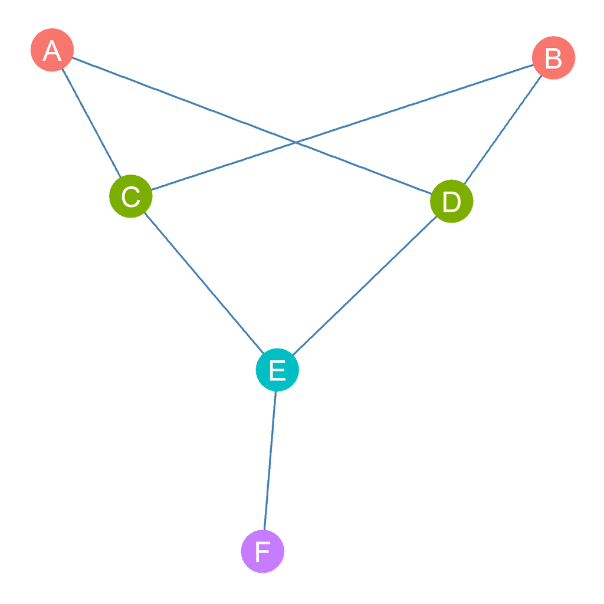

Figure 5.1: An undirected graph with nodes colored by membership in the same structural equivalence class.

## 5.1 Structural Equivalence

*Two nodes are structurally equivalent if they are connected to the same others*. Thus, their patterns of connectivity (e.g., their row in the adjacency matrix) is exactly the same.

For instance in Figure 5.1, nodes *C* and *D* are structurally equivalent because they are connected to the same neighbors $\{A, B, E\}$. In the same way, nodes *A* and *B* are structurally equivalent because they are connected to the same neighbors $\{C, D\}$. Finally, nodes *E* occupies *unique positions* in the network because their neighborhoods are not equivalent to that of any other nodes. Node *E* is the only node that has a neighborhood composed of nodes $\{C, D, F\}$, and node *F* is the only node that has a neighborhood composed of node $\{E\}$ only.

Table 5.1: Adjancency Matrix of an Undirected Graph

|  | A | B | C | D | E | F |
| --- | --- | --- | --- | --- | --- | --- |
| A | 0 | 0 | 1 | 1 | 0 | 0 |
| B | 0 | 0 | 1 | 1 | 0 | 0 |
| C | 1 | 1 | 0 | 0 | 1 | 0 |
| D | 1 | 1 | 0 | 0 | 1 | 0 |
| E | 0 | 0 | 1 | 1 | 0 | 1 |
| F | 0 | 0 | 0 | 0 | 1 | 0 |

We can also see by looking at Table 5.1 that, indeed, the rows corresponding to the structurally equivalent nodes $\{A, B\}$ and $\{C, D\}$ in the corresponding **adjacency matrix** are indistinguishable from one another.

## 5.2 Structural Similarity

In most real-world applications, the standard definition of structural equivalence is much too strong. In answer to the question of whether two nodes occuppy the same position in the network it only allows for a “yes/no” answer. Yes, if their neighborhoods are *exactly* the same, and “no” if there aren’t.

What we need is a measure of position that allows for “more or less” rather than “yes” and “no.” This is what is called **structural similarity** (Leicht, Holme, and Newman 2006). Two nodes are structurally similar if they have similar patterns of connectivity with the same others. There are various versions of structural similarity between nodes. Here we will consider some popular ones.

Leicht, Elizabeth A, Petter Holme, and Mark EJ Newman. 2006. “Vertex Similarity in Networks.” *Physical Review E* 73 (2): 026120.

As we noted in the original graph theory lesson, it is possible for the **neighborhood** of two nodes in a graph to *overlap*. Recall that for each node, we define its neighborhood as the set of other nodes that they are adjacent to. That means the neighborhood between two nodes can have members in common. The more members they have in common the more **structurally similar** two nodes are.

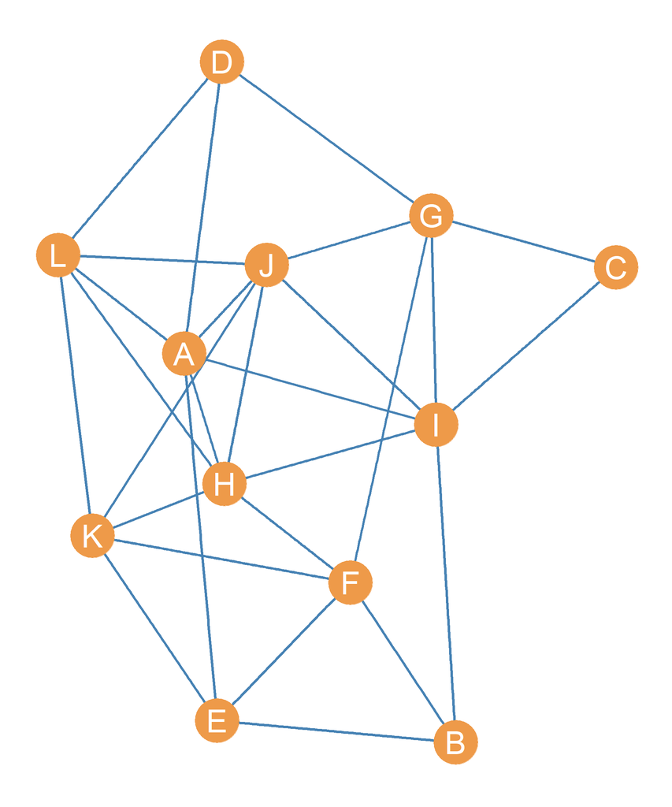

Figure 5.2: An undirected graph.

For instance, imagine you have a friend and that friend knows *all* your friends and you know *all* their friends. In which case we would say that the overlap between your node neighborhoods is pretty high; in fact the two neighborhoods overlap *completely*, which makes you structurally equivalent! But even if your friend knows 90% of the people in your network (and you know 90% of the people in their network) that would make you very structurally similar to one another. Now imagine you just met a new person online who lives in a far away country, and as far as you know, they know *none* of your friends and you know *none* of their friends. In which case, we would say that the overlap if the two neighborhoods is nil or as close to zero as it can get. You occupy completely different positions in the network.

### 5.2.1 Jaccard Similarity

We can use this reasoning to construct a measure of structural similarity between two nodes called **[Jaccard’s Similarity Coefficient](https://en.wikipedia.org/wiki/Jaccard_index)** ($J_{ij}$). It goes like this. Let’s say $n_{ij}$ is the number of friends that nodes *i* and *j* have in common, and the total number of *i*’s friends if $k_i$ (*i*’s degree) and the total number of *j*’s friends if $k_j$. Then the structural similarity of *i* and *j* is given by:

$$\begin{equation}
J_{ij} = \frac{n_{ij}}{k_i + k_j - n_{ij}}
\tag{5.1}
\end{equation}$$

It says that the structural similarity of two nodes is equivalent to the number of friends that the two persons know in common, divided by the sum of their degrees minus the number of people they know in common. Jaccard’s coefficient ranges from zer (when $n_{ij}=0$ and the two nodes have no neighbors in common) to 1.0 (when $n_{ij} = k_i$ and $n_{ij} = k_j$ and the two nodes are structurally equivalent).

### 5.2.2 Dice Similarity

A second measure of structural similarity between nodes is the **Dice Similarity Index**. This is given by:

$$\begin{equation}
D_{ij} = \frac{2n_{ij}}{k_i + k_j}
\tag{5.2}
\end{equation}$$

Which says that the structural similarity between two nodes is equivalent to the twice the number of people the know in common, divided by the sum of their degrees.

### 5.2.3 Cosine Similarity

A third and final measure of structural similarity between two nodes is the **cosine similarity** between their respective neighborhoods ($C_{ij}$). This is given by:

$$\begin{equation}
C_{ij} = \frac{n_{ij}}{\sqrt{k_ik_j}}
\tag{5.3}
\end{equation}$$

Which says that the structural similarity between two nodes is equivalent to the number of people they know in common divided by the square root of the product of their degrees (which is also referred to as the **geometric mean** of their degrees).

A lot of the times, these three measures of structural similarity will tend to agree. Tables 5.2, 5.3, 5.4 show the similarities between each pair of nodes in the graph depicted in Figure 5.2.

Table 5.2: Structural similarities for pairs of nodes in an undirected graph (Jaccard).

|  | A | B | C | D | E | F | G | H | I | J | K | L |
| --- | --- | --- | --- | --- | --- | --- | --- | --- | --- | --- | --- | --- |
| A | – | 0.29 | 0.14 | 0.12 | 0 | 0.22 | 0.38 | 0.33 | 0.2 | 0.33 | 0.57 | 0.38 |
| B | – | – | 0.25 | 0 | 0.17 | 0.14 | 0.33 | 0.29 | 0 | 0.12 | 0.33 | 0 |
| C | – | – | – | 0.25 | 0 | 0.17 | 0.17 | 0.14 | 0.14 | 0.33 | 0 | 0 |
| D | – | – | – | – | 0.17 | 0.14 | 0 | 0.29 | 0.29 | 0.5 | 0.14 | 0.14 |
| E | – | – | – | – | – | 0.29 | 0.12 | 0.43 | 0.25 | 0.25 | 0.12 | 0.29 |
| F | – | – | – | – | – | – | 0 | 0.1 | 0.38 | 0.38 | 0.25 | 0.25 |
| G | – | – | – | – | – | – | – | 0.38 | 0.22 | 0.1 | 0.25 | 0.25 |
| H | – | – | – | – | – | – | – | – | 0.2 | 0.5 | 0.38 | 0.38 |
| I | – | – | – | – | – | – | – | – | – | 0.33 | 0.22 | 0.38 |
| J | – | – | – | – | – | – | – | – | – | – | 0.22 | 0.38 |
| K | – | – | – | – | – | – | – | – | – | – | – | 0.25 |
| L | – | – | – | – | – | – | – | – | – | – | – | – |

Table 5.3: Structural similarities for pairs of nodes in an undirected graph (Dice).

|  | A | B | C | D | E | F | G | H | I | J | K | L |
| --- | --- | --- | --- | --- | --- | --- | --- | --- | --- | --- | --- | --- |
| A | – | 0.44 | 0.25 | 0.22 | 0 | 0.36 | 0.55 | 0.5 | 0.33 | 0.5 | 0.73 | 0.55 |
| B | – | – | 0.4 | 0 | 0.29 | 0.25 | 0.5 | 0.44 | 0 | 0.22 | 0.5 | 0 |
| C | – | – | – | 0.4 | 0 | 0.29 | 0.29 | 0.25 | 0.25 | 0.5 | 0 | 0 |
| D | – | – | – | – | 0.29 | 0.25 | 0 | 0.44 | 0.44 | 0.67 | 0.25 | 0.25 |
| E | – | – | – | – | – | 0.44 | 0.22 | 0.6 | 0.4 | 0.4 | 0.22 | 0.44 |
| F | – | – | – | – | – | – | 0 | 0.18 | 0.55 | 0.55 | 0.4 | 0.4 |
| G | – | – | – | – | – | – | – | 0.55 | 0.36 | 0.18 | 0.4 | 0.4 |
| H | – | – | – | – | – | – | – | – | 0.33 | 0.67 | 0.55 | 0.55 |
| I | – | – | – | – | – | – | – | – | – | 0.5 | 0.36 | 0.55 |
| J | – | – | – | – | – | – | – | – | – | – | 0.36 | 0.55 |
| K | – | – | – | – | – | – | – | – | – | – | – | 0.4 |
| L | – | – | – | – | – | – | – | – | – | – | – | – |

Table 5.4: Structural similarities for pairs of nodes in an undirected graph (cosine).

|  | A | B | C | D | E | F | G | H | I | J | K | L |
| --- | --- | --- | --- | --- | --- | --- | --- | --- | --- | --- | --- | --- |
| A | – | 0.47 | 0.29 | 0.24 | 0 | 0.37 | 0.55 | 0.5 | 0.33 | 0.5 | 0.73 | 0.55 |
| B | – | – | 0.41 | 0 | 0.29 | 0.26 | 0.52 | 0.47 | 0 | 0.24 | 0.52 | 0 |
| C | – | – | – | 0.41 | 0 | 0.32 | 0.32 | 0.29 | 0.29 | 0.58 | 0 | 0 |
| D | – | – | – | – | 0.29 | 0.26 | 0 | 0.47 | 0.47 | 0.71 | 0.26 | 0.26 |
| E | – | – | – | – | – | 0.45 | 0.22 | 0.61 | 0.41 | 0.41 | 0.22 | 0.45 |
| F | – | – | – | – | – | – | 0 | 0.18 | 0.55 | 0.55 | 0.4 | 0.4 |
| G | – | – | – | – | – | – | – | 0.55 | 0.37 | 0.18 | 0.4 | 0.4 |
| H | – | – | – | – | – | – | – | – | 0.33 | 0.67 | 0.55 | 0.55 |
| I | – | – | – | – | – | – | – | – | – | 0.5 | 0.37 | 0.55 |
| J | – | – | – | – | – | – | – | – | – | – | 0.37 | 0.55 |
| K | – | – | – | – | – | – | – | – | – | – | – | 0.4 |
| L | – | – | – | – | – | – | – | – | – | – | – | – |

## 5.3 Structural Similarity in Directed Graphs

Similarity works in similar (pun intended) ways when studying asymmetric ties in directed graph. The main difference, as usual, is that in a directed graph pairs of nodes can structurally similar in two different ways. Fist, pairs of nodes can be similar with respect to their out-neighborhoods, in which case we say that nodes are structural similar if they point to the same set of neighbors. This is called the **out-similarity**. Second, pairs of nodes can be similar with respect to their in-neighborhoods, in which case we say that nodes are structural similar if they *receive* ties or nominations from the same set of neighbors. This is called the **in-similarity**.

Special cases of the out and in-similarities between nodes show up in particular types of networks. For instance, consider an information network composed of scientific papers. Here a directed tie emerges when paper *A* *cites* or refers to paper *B*. This is called a **citation network**.

In a citation network out-similar papers are papers that *cite* the same other papers. Out-similar papers are said to exhibit **bibliographic coupling** (essentially the overlap or set intersection between their reference lists). A weighted network of similarities between papers, where the weight of the edge is the number of other papers that that they both cite in common is called a **bibliographic coupling network**. A bibliographic coupling network is essentially a network of out-similarities between papers in a scientific information network.

In a citation network, in-similar papers are papers that *get cited* by the same set of others. In this case, we say that the two papers are **co-cited** a third paper. A weighted network of similarities between papers, where the weight of the edge is the number of other papers that cite both of them is called **co-citation network**. A co-citation network is essentially a network of in-similarities between papers in a scientific information network.

The two measures of out and in-similarities can be defined in the same way as before. If $n^{out}_{ij}$ is the number of common out-neighbors of nodes *i* and *j* and $n^{in}_{ij}$ is the number of their common out-neighbors, $k_{out}$ is the total number of out-neighbors of a particular node, and $k_{in}$ is the total number of in-neighbors, then the structural out and in-similarities between pairs of nodes *i* and *j* are given by (using the cosine distance measure) by:

$$\begin{equation}
C_{ij}^{out} = \frac{n_{ij}^{out}}{\sqrt{k_i^{out}k_j^{out}}}
\tag{5.4}
\end{equation}$$

$$\begin{equation}
C_{ij}^{in} = \frac{n_{ij}^{in}}{\sqrt{k_i^{in}k_j^{in}}}
\tag{5.5}
\end{equation}$$